# **PUSH OR PULL? THE INFLUENCE OF ICT ON EMIGRATION FLOWS**

# **WELCOME TO OUR WEBPAGE**

Thank you for showing interest in our research project!

Our names are Ana M. and Ayra R. and together we are conducting a brief study on the the factors that influence migration. Particularly, this research explores how changes in the 20th century have changed the flows of migration. We are trying to answer the following question: **Has Information, communication and technology (ICT) impact the flow of migration?**

[output not shown]

# **WHY ARE WE STUDYING ICT AND MIGRATION?**

Migration is broadly defined as a permanent or semi-permanent relocation of residence, there are no restrictions placed upon the distance or voluntary or involuntary nature of moving [@Lee1966]. For many years, the idea of international migration meant disconnecting with one’s homeland. This meant the process of communication with friends and family left behind was a slow process, often via hand written letters. However, since the dawn the digital age at the start of the 20th century information and communication technology (ICT) has radically changed the speed and nature of interactions between people worldwide.

ICT and the emergence of globalisation has impacted every facet of our daily lives, we want to observe if it has affected the why people move and why people stay.

# **PUSH AND PULL**

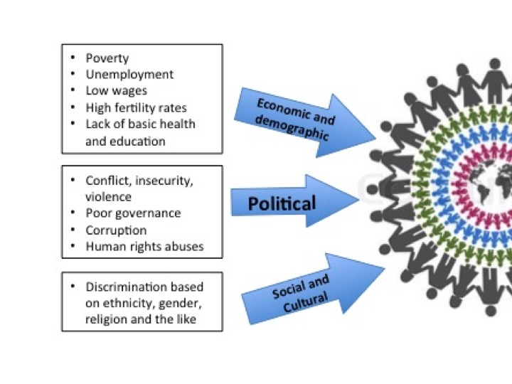

- Push factors are reasons that are generally forced and negative, these factors are associated with the country of origin. People are ‘pushed’ to leave their homeland for a number of varying reasons.

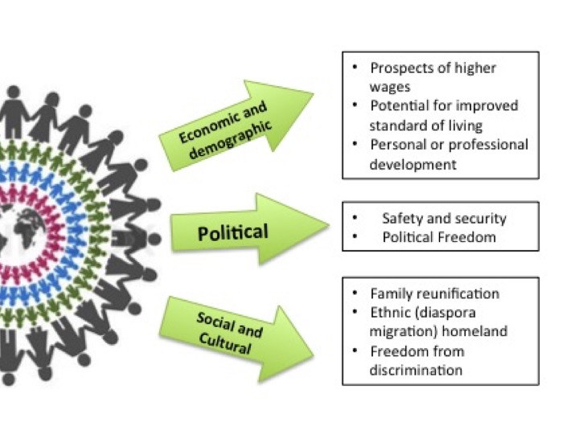

- Pull factors on the other hand are the positive traits that positively affect the movement of people. Often people are drawn to move to places to escape the negative factors pushing them out.

# **THE DATA**

1. **International Migrant Stock** from the United Nations from 2000, 2010 and 2013
2. **Internet Users** and the number of **cellphone subscriptions** for each country collected from the World Bank as proxy variables for ICT
3. World Bank Indicators to control for social, economic and political factors:
- **Fertility Rate:** Total fertility rate represents the number of children that would be born to a woman if she were to live to the end of her childbearing years and bear children in accordance with current age-specific fertility rates.
- **Employment Probability:** Calculated using the 1- the employment rate [@Mayda2005].
- **Political Stability:** Political Stability and Absence of Violence/Terrorism measures perceptions of the likelihood of political instability and/or politically-motivated violence, including terrorism.

# **OUR METHOD**

The best model for our research is a panel regression with fixed effects.

For more information please refer to our paper: https://github.com/ARowena/Final_ProjectMontesReyla/blob/master/Final_Paper_.pdf

If you’re more curious about statistical models, here are also few useful links: http://www.indiana.edu/~wim/docs/10_7_2011_slides.pdf or http://gauss.stat.su.se/gu/e/slides/F17.pdf

# **WHAT DID WE LEARN?**

The increase in the use of technology has had important effect on how people communicate now a days. AS Castles (2009) points out social transformations are tighly related with ICT development. This paper intents to explore the relationship between migration flows and ICT’s using the number of cellphone subscription and Internet users as proxies for Information and Communication Technology. We take advantage of both the time series and cross-country variation in our data set. Our results show that countries with higher Internet Users has on overage higher emigration rates and that this relationship is stronger as Internet use deepens in the latest decade when compared to the 2000’s. Moreover, as the use of Cellphone penetrates in the country’s inside markets, emigration rates tends to be higher. The diferences in emigration rates between countries, however, are not explained by the number of Cellophone users.

Nevertheless, as there are many reasons why individuals choose to migration, and communication technologies could make this process much more easy and attractive. It is benificial for countries or governments to undestand the causes and the drivers for migration so that they can futher learn and develop strategies to either retain or atract population in their borders, depending on trends currently happening around the globe. Mobile and internet technology are also resources that governments can exploitto communicate policies and information for people interesting in migrating, making integration process more easy for them.

# **… WHAT ARE THE NEXT STEPS?**

The United Nations (UN) have complied a large amount of statistical evidence on the topic of migration, however, the database does not have a large number of year observations. One of the major next steps is to select a longer year frame database. Moreover, we wouldlike to access and explore good and reliable datasets in order to study if the use of ICT influence people’s opinion and experience of migration at the individual level.

# **Interested in learning more?**

This topic has grown increasing relevance as awareness and data of people’s movements are more easily captured. There are a lot resources online, but here are a few links we though were interesting. Have a look, learn and enjoy!

Interactive website that visually displays migration flows: http://peoplemov.in/

Interested in policy?: http://www.migrationpolicy.org/programs/data-hub/maps-immigrants-and-emigrants-around-world or http://www.mipex.eu

Academic articles and relevant books: - World Catalogue: http://tinyurl.com/okosesf - Webinars: http://www.migrationpolicy.org/

Starting point books: 1. The Age of Migration: http://tinyurl.com/or4mkg8 (very comprehensive book) 2. International Migration: A very short introduction: http://tinyurl.com/o4qutw8 (with good suggestions of list of further readings) 3. Tyranny of Experts: Chapter on Migration